# Random Samples, Central Limit Theorem, and Estimators

Ana Baide and Jacob Kuney

In this project, we will work with the sampling distributions of statistics, the Central Limit Theorem (CLT), and properties of estimators.

The Central Limit Theorem and the properties of estimators are one of the most powerful concepts/tools that we learn in this course. It will send you back to the beginning of this class, require you to remind yourself and use the distributions and probability principles that we studied then, and yet at the end of this class now, it will set the stage for new beginnings for many things to come. Make sure to have fun, and good luck!

# 1 Sampling Distribution of a Statistic.

Given sample data of the form:
$$X= \{x_1, x_2, x_3, \dots, x_n\},$$
consider the following statistic:
$$\hat{\theta}(X) = \frac{\sum_{i=1}^n (x_i - \overline{x})^2}{n}.$$
Note that this statistic can be an “estimator” for the population variance $\sigma^2$. For now, write a function “theta_hat” that calculates the value of the statistic given sample data “samp”.

```r
theta_hat <- function(samp){
x = samp
draws = sample(x, size = 100, replace = TRUE, prob = NULL)
}
```

Use the replicate and hist function to calculate the sampling distribution of $\hat{\theta}$ when working with random samples coming from $N(\mu = 5, \sigma = 1.5)$ of sizes $n = 2, 3, 5, 10, 50, 500$.

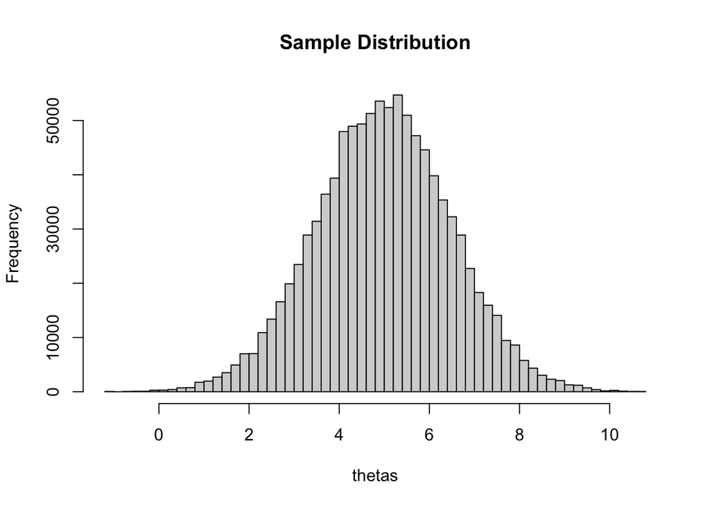

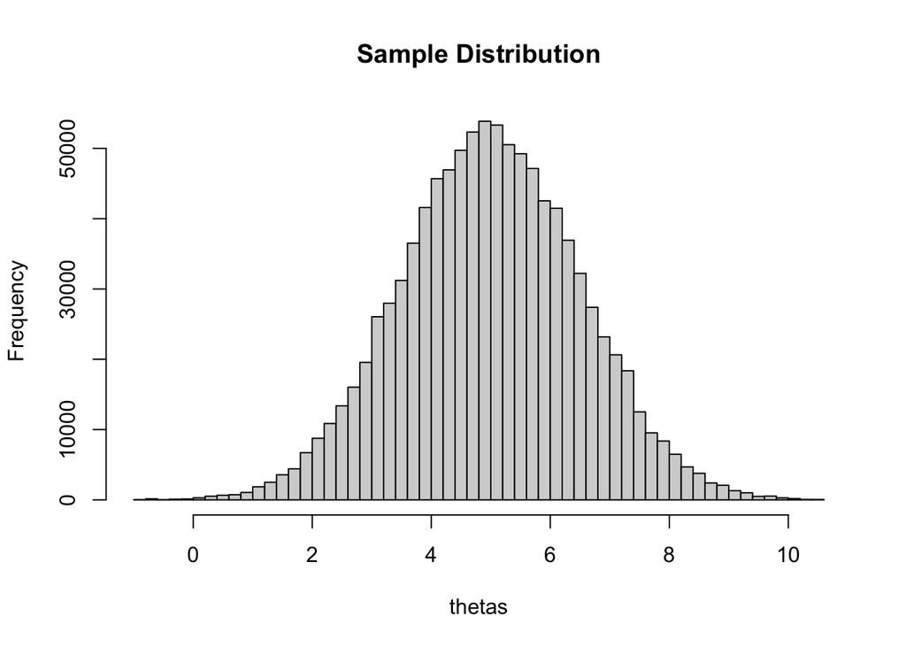

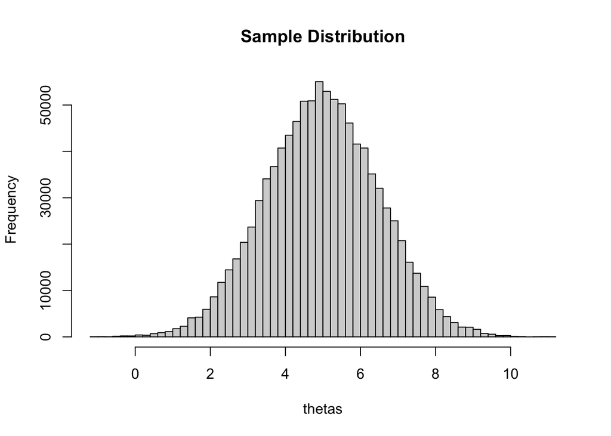

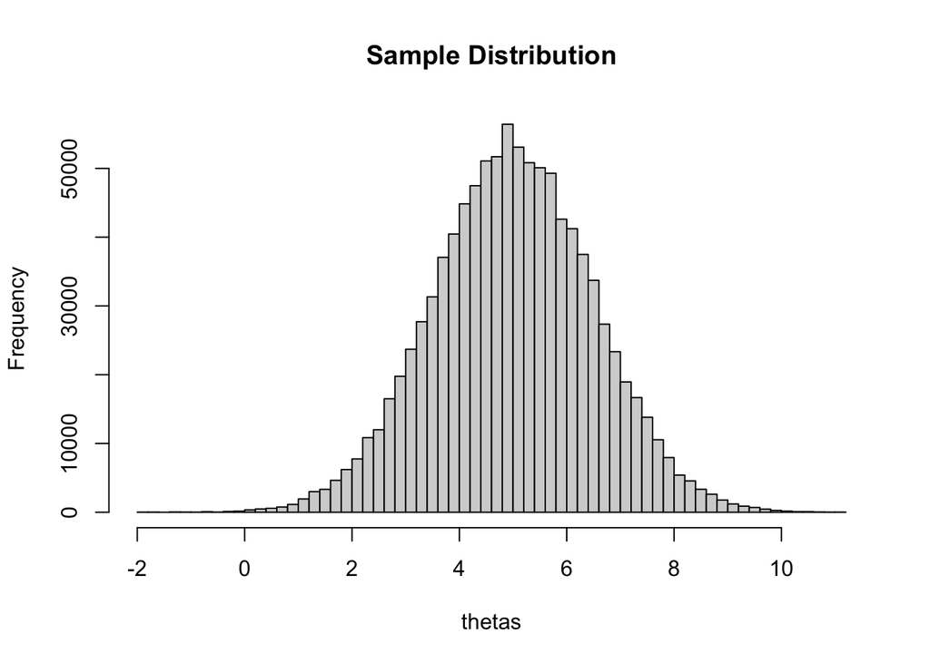

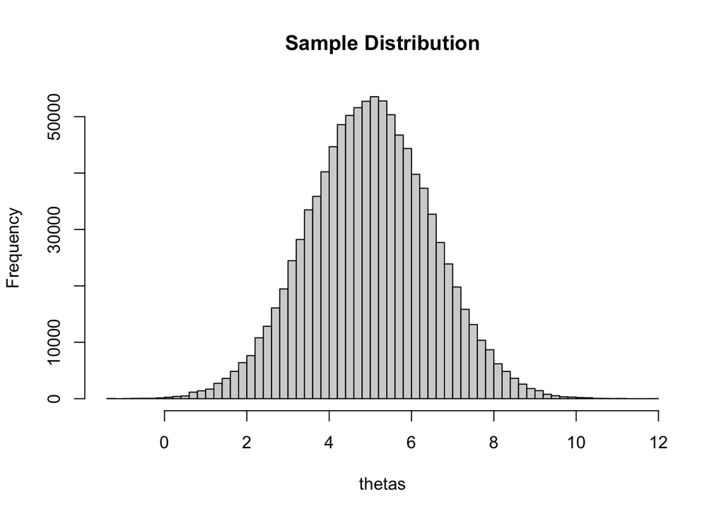

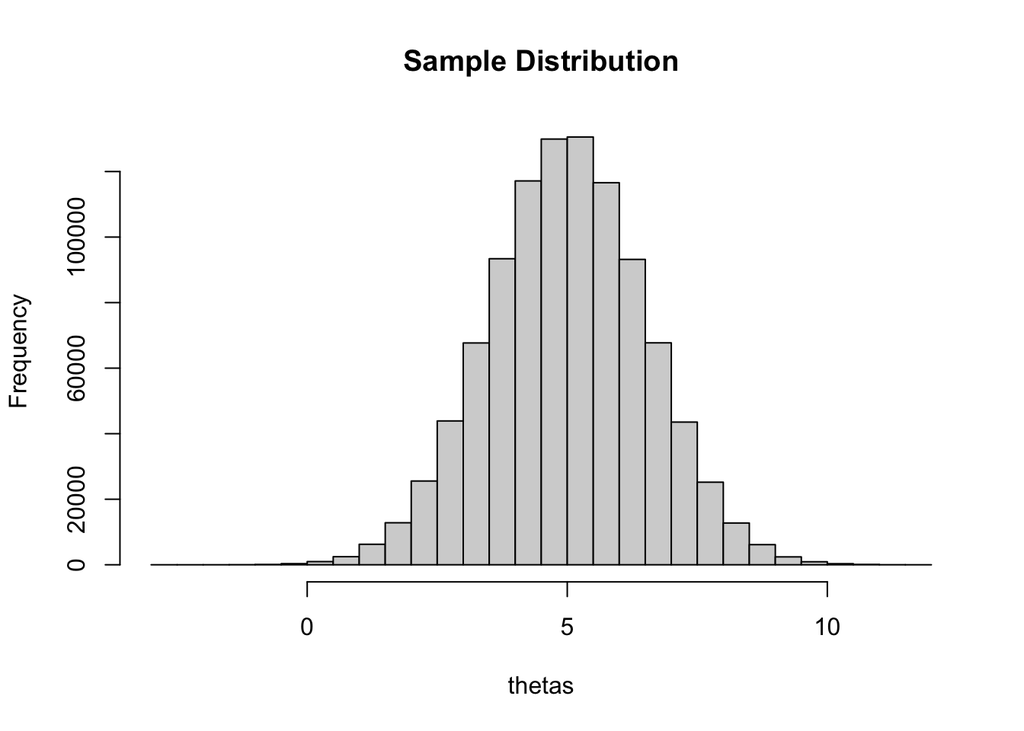

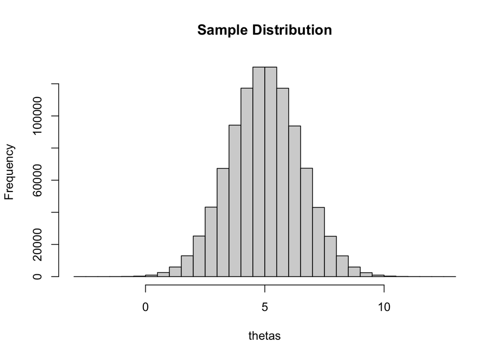

```r
B <- 10000
sizes <- c(2, 3, 4, 5, 10, 50 ,500)
mu <- 5
sigma = 1.5

for(n in sizes){
  thetas <- replicate(B, {
    samp <- rnorm(n, mu, sigma)
    theta_hat(samp)
  })
  hist(thetas, breaks = 50,
       main = "Sample Distribution")
  }
```

For each of these cases of sample sizes, calculate the empirical expected value.

```r
B <- 10000
sizes <- c(2, 3, 4, 5, 10, 50 ,500)

for(n in sizes){
  thetas <- replicate(B, {
    samp <- rnorm(n, mu, sigma)
    theta_hat(samp)
  })
  print(paste("Sample size:",  n, "Empirical exp value of theta_hat ", round(mean(thetas), 5)))
  }
```

```
## [1] "Sample size: 2 Empirical exp value of theta_hat  4.9983"
## [1] "Sample size: 3 Empirical exp value of theta_hat  5.00555"
## [1] "Sample size: 4 Empirical exp value of theta_hat  5.00562"
## [1] "Sample size: 5 Empirical exp value of theta_hat  5.00008"
## [1] "Sample size: 10 Empirical exp value of theta_hat  5.00772"
## [1] "Sample size: 50 Empirical exp value of theta_hat  5.00114"
## [1] "Sample size: 500 Empirical exp value of theta_hat  4.99759"
```

As sample size increases what is the relation between the empirical mean of $\hat{\theta}$ and $\sigma^2$?

# 2 Central Limit Theorem

## 2.1 Exponential Distribution

Suppose we are working with a population that has the exponential distibution with $\lambda = 2$.

Use the replicate function to get the histograms for the sampling distribution of the sample mean when working with sample sizes $n = 1, 2, 3, 4, 15, 500$. Be sure to have appropriate titles for your histograms.

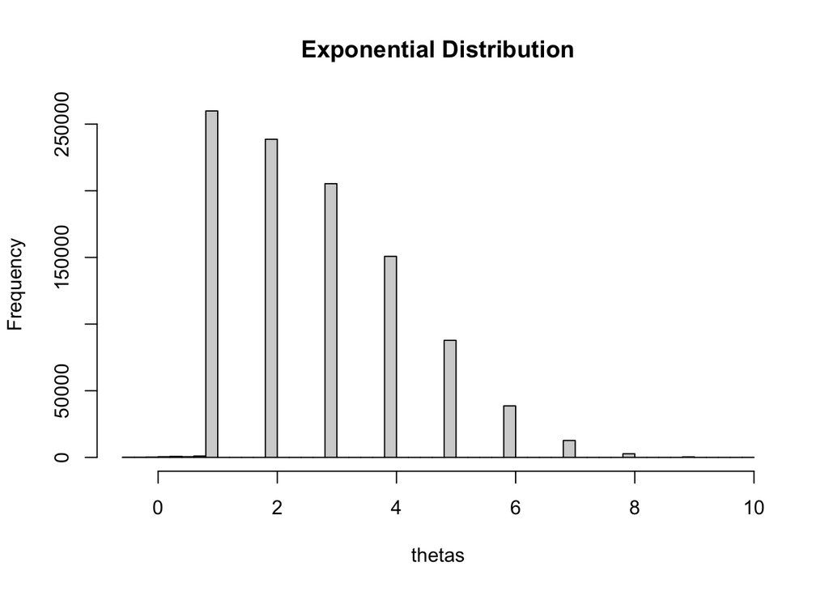

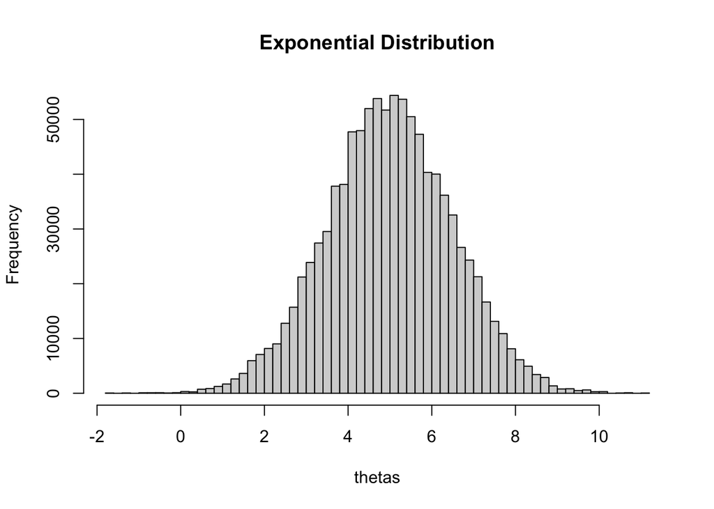

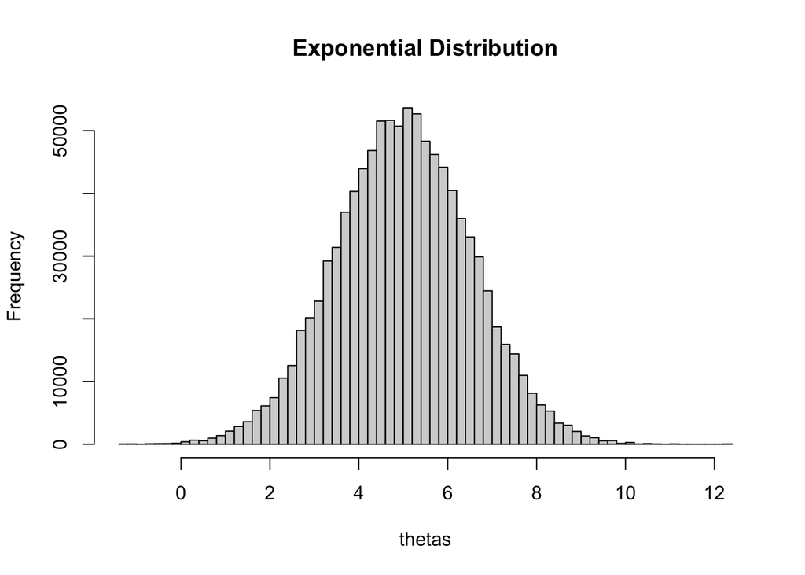

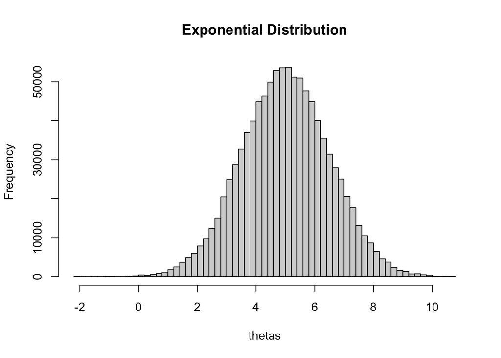

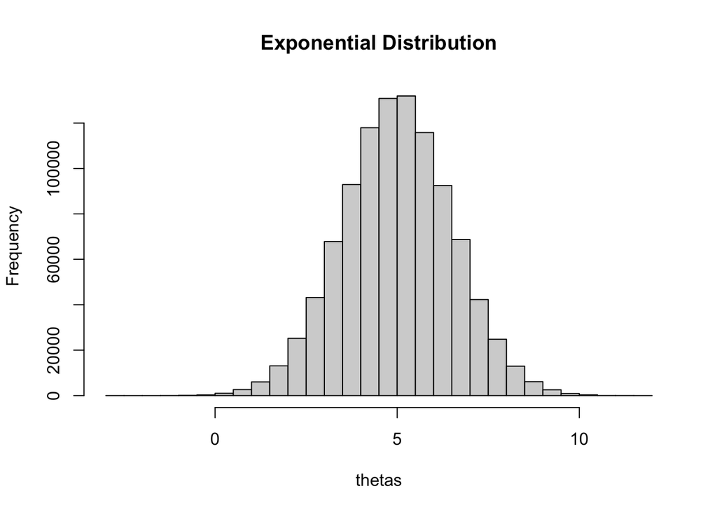

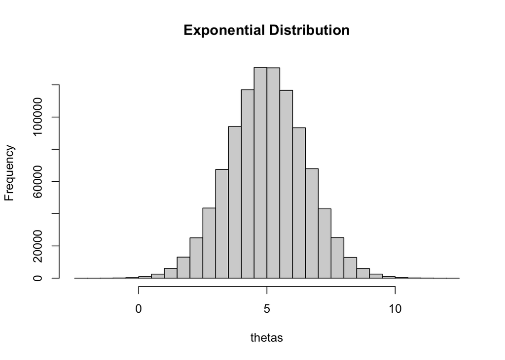

```r
B <- 10000
 sizes <- c(1, 2, 3, 4, 15, 500)
 mu <- 5
 sigma <- 1.5

 for(n in sizes){
   thetas <- replicate(B, {
     samp <- rnorm(n, mu, sigma)
     theta_hat(samp)
   })
   hist(thetas, breaks = 50,
        main = "Exponential Distribution", axes= TRUE)
   }
```

What do you notice?

The ploting starts different but then it changes to a different shape.

## 2.2 Discrete Uniform distibution

Suppose we are working with the discrete uniform random variable taking values $\{1, 2, 3, 4, 5, 6\}$.

Define a function “disc_samp” that takes input “n” and returns a random sample of size “n” from this distribution.

```r
n <- c(1, 2, 3, 4 , 5, 6)
disc_samp <- function(n){
x = n;
draws = sample(x, n, replace = TRUE)
}
```

Use the “disc_samp” function and the replicate function to to get the histograms for the sampling distribution of the sample mean when working with sample sizes $n = 1, 2, 3, 4, 15, 500$. Be sure to have appropriate titles for your histograms.

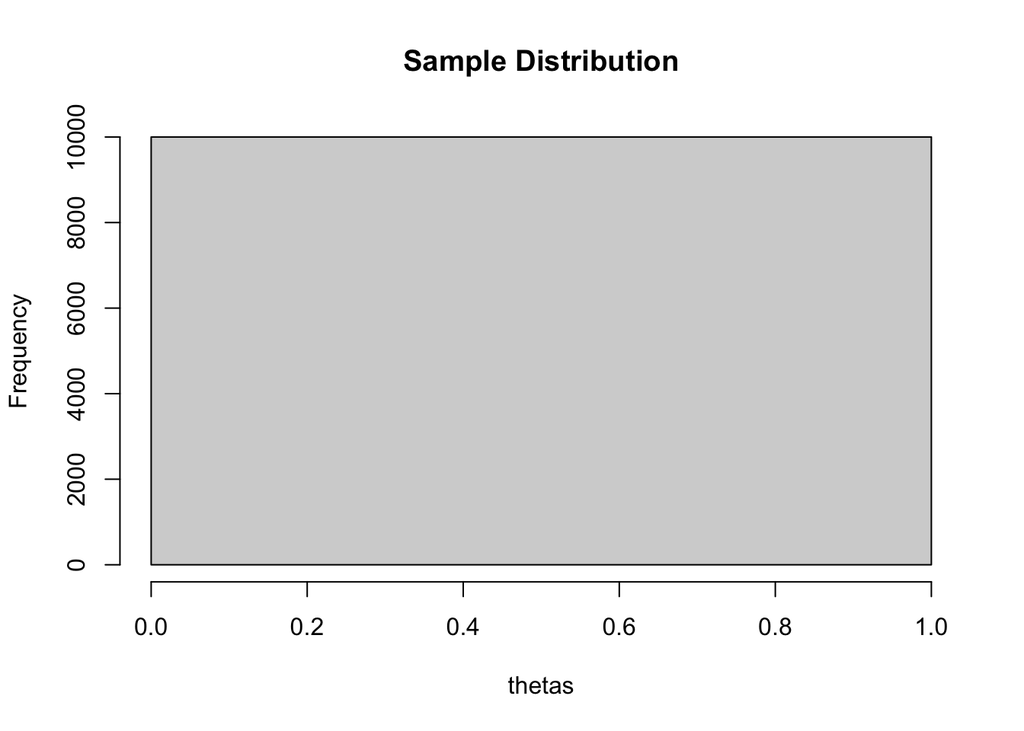

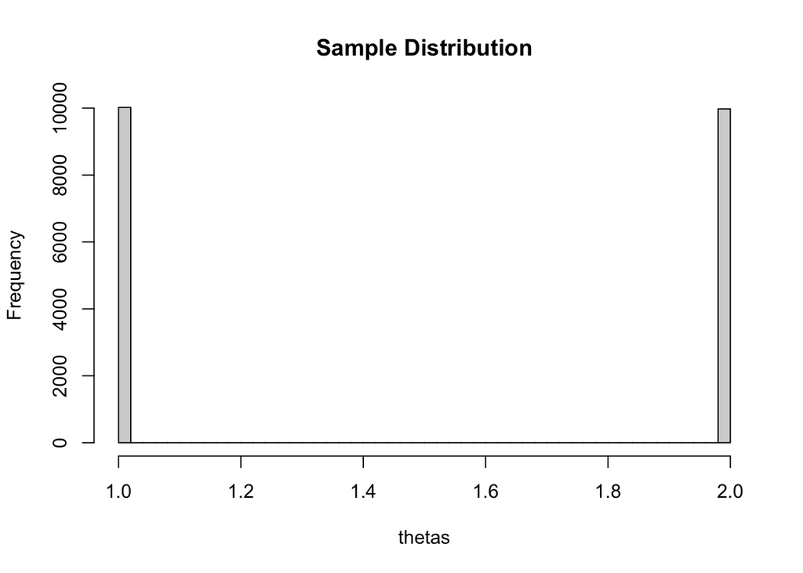

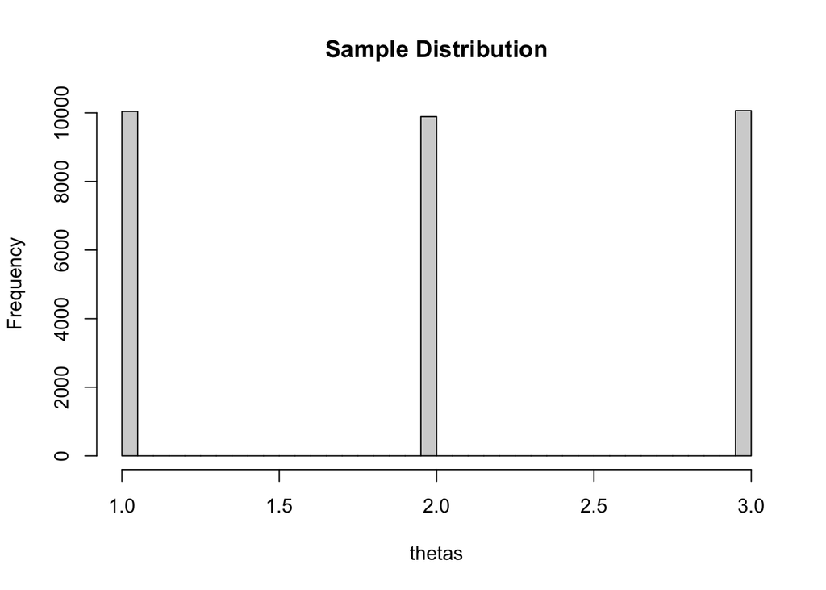

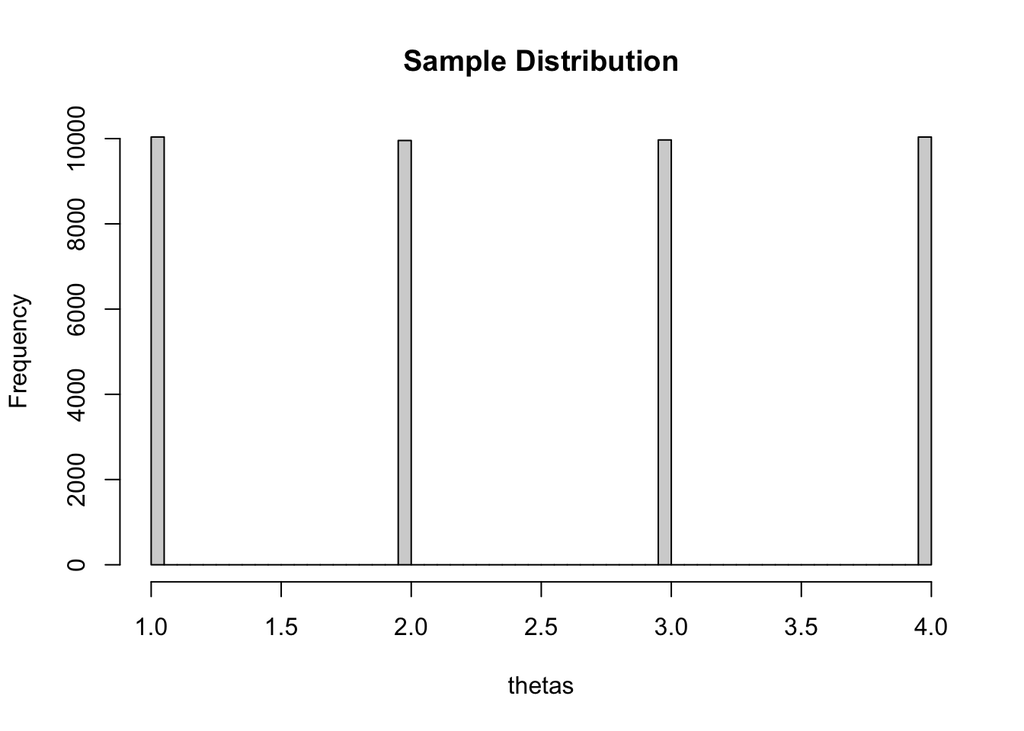

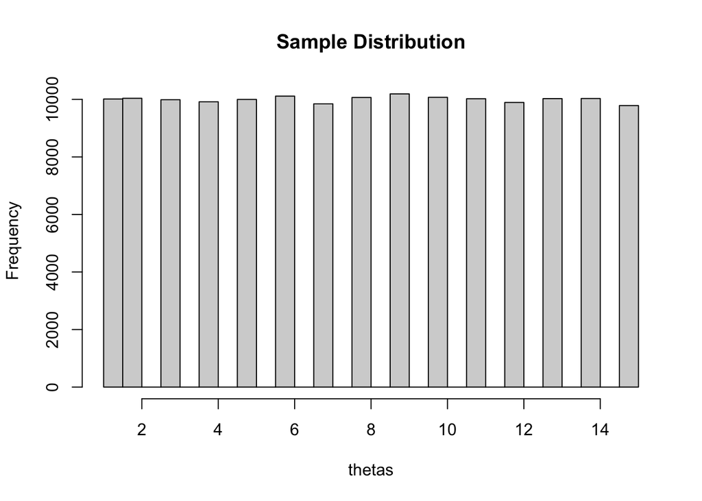

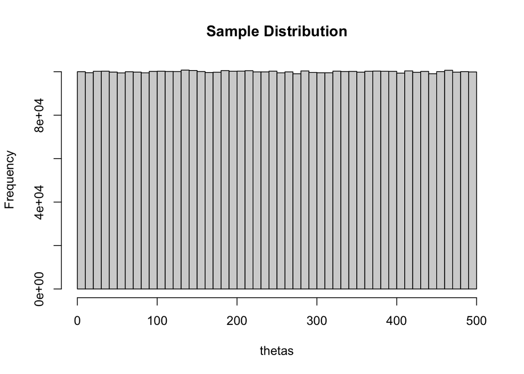

```r
B <- 10000
 sizes <- c(1, 2, 3, 4, 15, 500)
 mu <- 5
 sigma <- 1.5

 for(n in sizes){
   thetas <- replicate(B, {
     samp <- rnorm(n, mu, sigma)
     disc_samp(n)
   })
   hist(thetas, breaks = 50,
        main = "Sample Distribution")
   }
```

What do you notice?

## 2.3 Continuous Uniform distibution

Suppose we are working with the Continuous uniform random variable taking values on $(0,1)$.

Define a function “cont_uni_samp” that takes input “n” and returns a random sample of size “n” from this distribution.

```r
cont_uni_samp <- function(n){
x = n;
draws = sample(x, replace = TRUE)
}
```

Use the “cont_uni_samp” function and the replicate function to to get the histograms for the sampling distribution of the sample mean when working with sample sizes $n = 1, 2, 3, 4, 15, 500$. Be sure to have appropriate titles for your histograms.

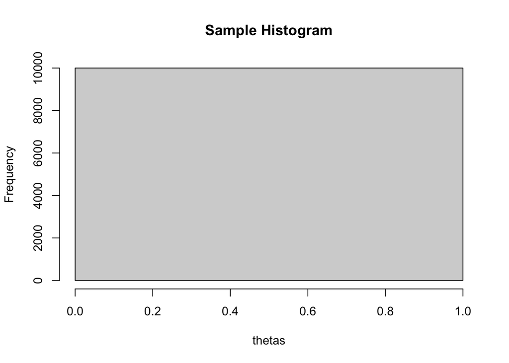

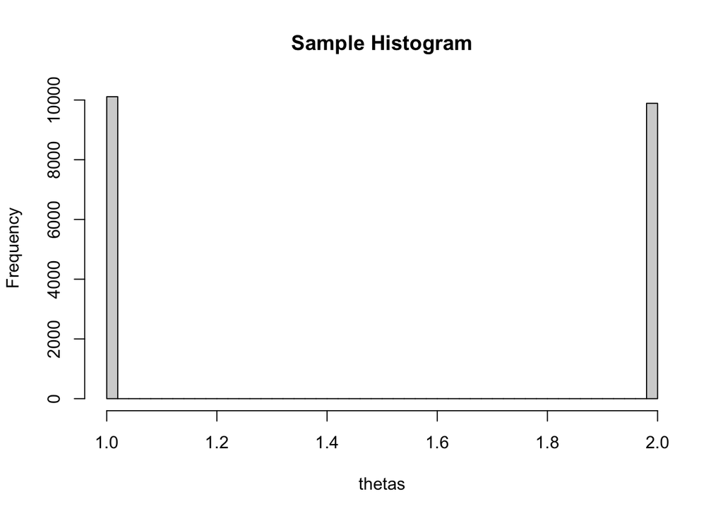

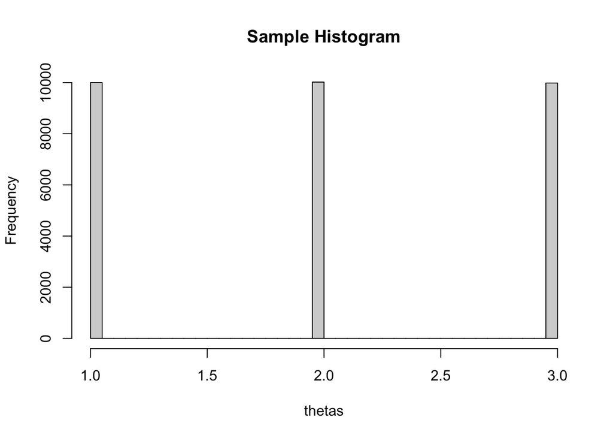

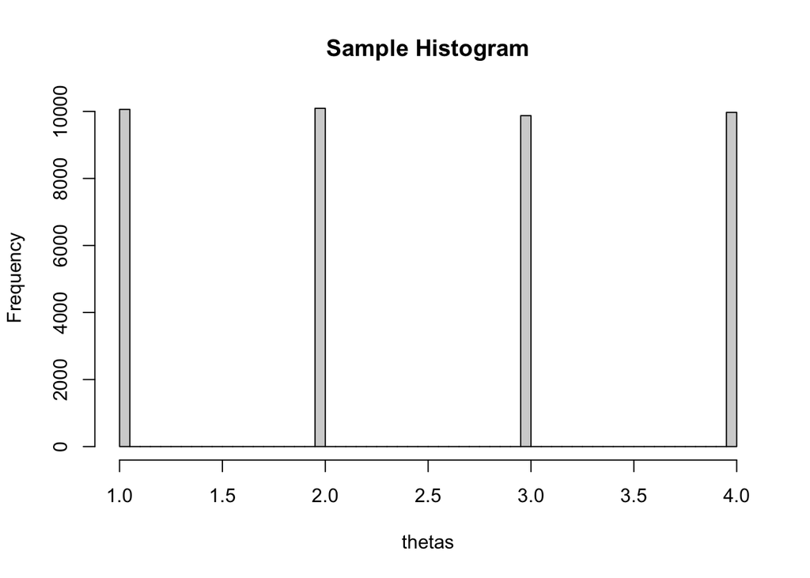

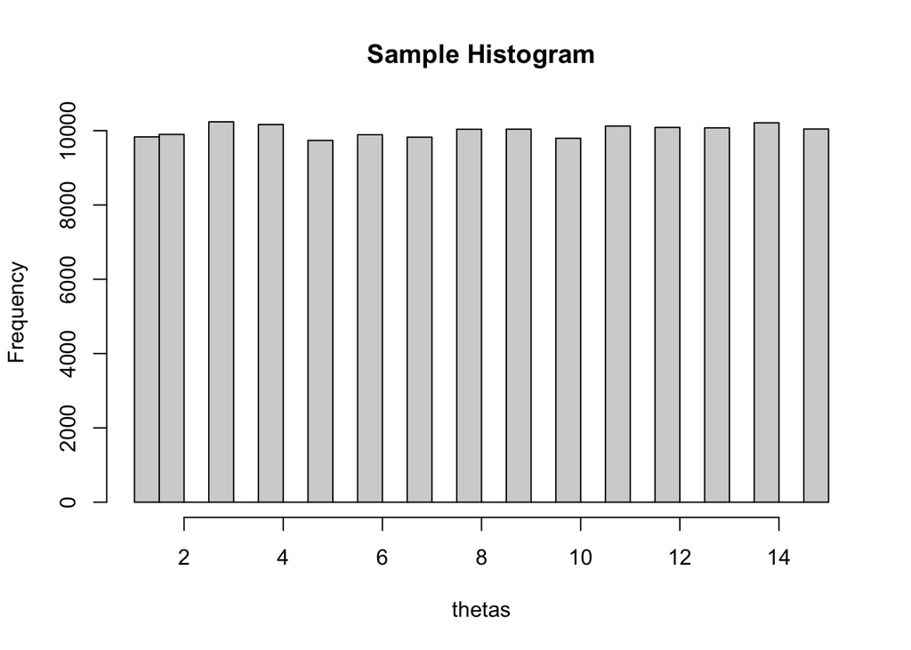

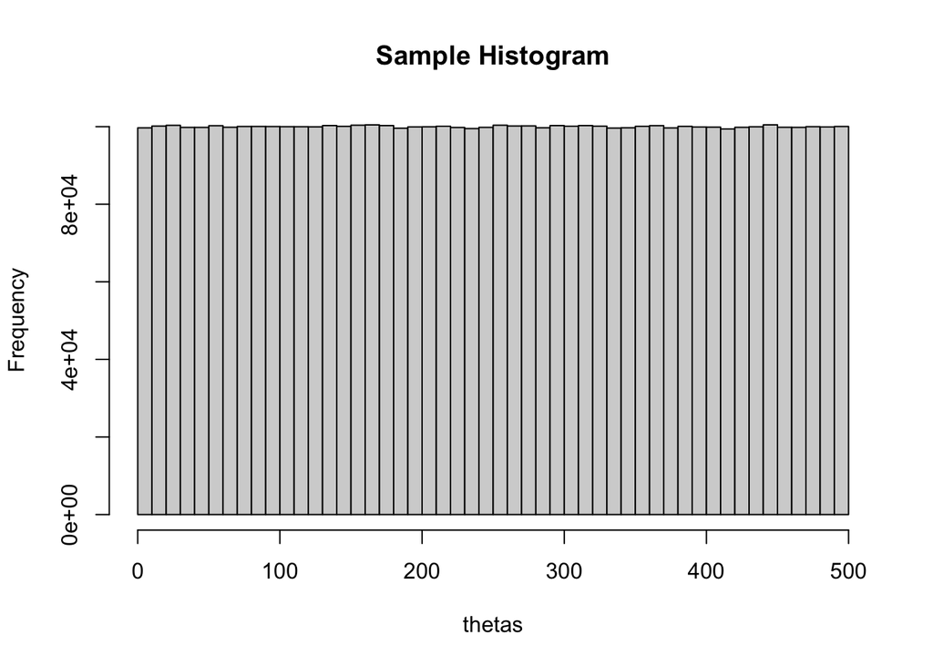

```r
sizes <- c(1,2,3,4,15,500)

 for(n in sizes){
   thetas <- replicate(B, {
     samp <- cont_uni_samp(n)
   })
   hist(thetas, breaks = 50,
        main = "Sample Histogram")
   }
```

What do you notice?

# 3 Estimators for the Gamma parameters

Recall from class that we calculated the estimators for $\alpha$ and $\beta$ using the method of moments for a sample of data values of size $n$ as:
$$\hat{\alpha} = \frac{\overline{X}^2}{(1/n)\sum X_i^2 - \overline{X}^2}\quad \hat{\beta} = \frac{(1/n)\sum X_i^2 - \overline{X}^2}{\overline{X}}$$

Write functions “alpha_hat” and “beta_hat” that take input a sample of data values “samp” and output the given estimators.

```r
alpha_hat <- function(samp){
  mean_sq <- (mean(samp))^2
  sum_sq <- sum(samp^2)
  estimate <- mean_sq/((1/length(samp))*sum_sq - mean_sq)
  return(estimate)
}

beta_hat <- function(samp){
  mean_sq <- (mean(samp))^2
  sum_sq <- sum(samp^2)
  estimate <- ((1/length(samp))*sum_sq - mean_sq)/mean_sq
  return(estimate)
}
```

Now let’s work with a Gamma distribution with $\alpha = 2$ and $\beta = 4$.

## 3.1 Bias, Variance, and MSE of Gamma Estimators.

Recall that we calculated the following identity in class:
$$\rm{MSE}(\hat{\theta}) = V(\hat{\theta}) + (\rm{Bias}(\hat{theta}))^2.$$
This problem will empirically verify this identity. \

```r
alpha_hat <- function(samp){
   mean_sq <- (mean(samp))^2
   sum_sq <- sum(samp^2)
   estimate <- mean_sq / ((1/length(samp)) * sum_sq - mean_sq)
   return(estimate)
 }

 beta_hat <- function(samp){
   mean_sq <- (mean(samp))^2
   sum_sq <- sum(samp^2)
   estimate <- ((1/length(samp)) * sum_sq - mean_sq)/mean(samp)
   return(estimate)
 }
```

Now let’s work with a Gamma distribution with $\alpha = 2$ and $\beta = 4$.

## 3.2 Bias, Variance, and MSE of Gamma Estimators.

Use the replicate function to calculate the empirical variance and bias of the estimators $\hat{\alpha}$ and $\hat{\beta}$ when sampling a sample of size 30 from $\rm{Gamma}(\alpha = 2, \beta = 4)$. Store these numbers in variables “var_emp” and “bias_emp”.

```r
B <- 10000
size <- 30
alpha <- 2
beta <- 4

alpha_hats <- replicate(B, {
  samp <- rgamma(size, shape = 2, scale = 4)
  alpha_hat(samp)
  })
alpha_var_emp <- mean((alpha_hats - mean(alpha_hats))^2)
alpha_var_emp
```

```
## [1] 0.4834626
```

```r
alpha_bias_emp <- mean((alpha_hats - 2))
alpha_bias_emp
```

```
## [1] 0.2954537
```

```r
beta_hats <- replicate(B, {
  samp <- rgamma(size, shape = 2, scale = 4)
  beta_hat(samp)
  })

beta_var_emp <- mean((beta_hats - mean(beta_hats))^2)
beta_var_emp
```

```
## [1] 1.667081
```

```r
beta_bias_emp <- mean((beta_hats - 4))
beta_bias_emp
```

```
## [1] -0.1823617
```

Use the replicate function to calculate the Mean Squared Error for $\hat{\alpha}$ and $\hat{\beta}$ when sampling a sample of size 30 from $\rm{Gamma}(\alpha = 2, \beta = 4)$. Store this number in “MSE_emp”.

```r
alpha_hats <- replicate(B, {
  samp <- rgamma(size, shape = 2, scale = 4)
  alpha_hat(samp)
  })

alpha_MSE_emp <- mean((alpha_hats - alpha)^2)
alpha_MSE_emp
```

```
## [1] 0.5614116
```

```r
beta_hats <- replicate(B, {
  samp <- rgamma(size, shape = 2, scale = 4)
  beta_hat(samp)
  })

beta_MSE_emp <- mean((beta_hats - beta)^2)
beta_MSE_emp
```

```
## [1] 1.651815
```

```r
alpha_var_emp + alpha_bias_emp
```

```
## [1] 0.7789163
```

```r
alpha_MSE_emp
```

```
## [1] 0.5614116
```

```r
beta_var_emp + beta_bias_emp
```

```
## [1] 1.48472
```

```r
beta_MSE_emp
```

```
## [1] 1.651815
```